# EDA-Multiple Linear Regression Models

Harper Wang

4/30/2022

```r
# install packages for running code.
library(tidyverse)
library(readr)
library(dplyr)
library(readxl)
library(tinytex)
library(tibble)
library("GGally")
```

```r
library(ggplot2)
library(psych)
# Add a new section which is variables' name to original data
cols <- c("CIC0","SM1_Dz(Z)","GATS1i","NdsCH","NdssC","MLOGP","LC50 [-LOG(mol/L)]")
fish <- read_delim("/Users/auntbreakfast/Desktop/NSCU Undergrads/ST308/qsar_fish_toxicity.csv", col_names = cols, na = c('.','NA'))
```

## provide a ‘pairs’ style plot using the GGally package

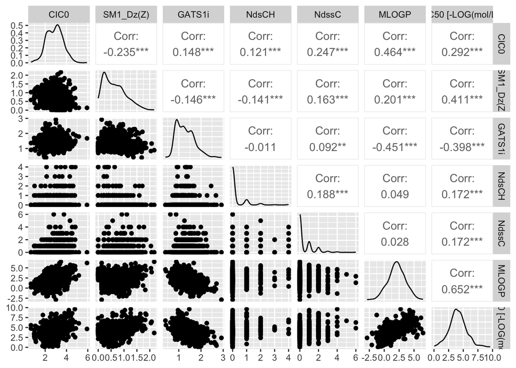

```r
ggpairs(fish)
```

## have numeric summaries of the LC50 variable (at different levels/combinations of other variables)

```r
summary <- fish %>%
  group_by(GATS1i,CIC0)%>%
  summarise(minimum = min(`LC50 [-LOG(mol/L)]`),
          mean = mean(`LC50 [-LOG(mol/L)]`),
          median = median(`LC50 [-LOG(mol/L)]`),
          maximun = max(`LC50 [-LOG(mol/L)]`))
summary
```

```
## # A tibble: 731 × 6
## # Groups:   GATS1i [557]
##    GATS1i  CIC0 minimum  mean median maximun
##     <dbl> <dbl>   <dbl> <dbl>  <dbl>   <dbl>
##  1  0.396  2.09    6.72  6.72   6.72    6.72
##  2  0.421  1.92    5.59  5.59   5.59    5.59
##  3  0.523  1.89    4.74  4.74   4.74    4.74
##  4  0.595  1.92    4.70  4.70   4.70    4.70
##  5  0.618  2.80    6.25  6.25   6.25    6.25
##  6  0.648  1.42    4.42  4.42   4.42    4.42
##  7  0.653  1.89    4.34  4.34   4.34    4.34
##  8  0.7    3.74    7.35  7.35   7.35    7.35
##  9  0.702  3.26    6.30  6.30   6.30    6.30
## 10  0.709  1.96    5.29  5.29   5.29    5.29
## # ℹ 721 more rows
```

## Plotting

1. The first plot is a scatter plot with a regression line. Which shows LC50 changes in diffrent CIC0 values.

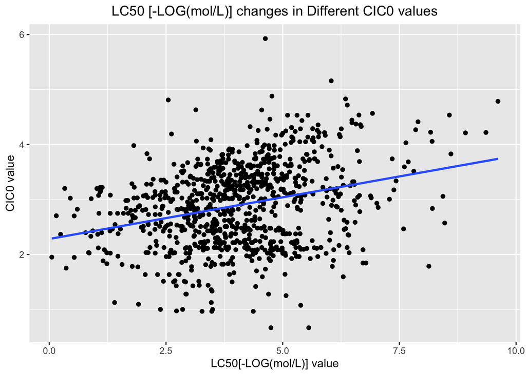

```r
g <- ggplot(fish, aes(x = `LC50 [-LOG(mol/L)]`, y = CIC0))
g + geom_point() +geom_smooth(formula = y ~ x, method = "lm", se = FALSE)+
  labs(title = "LC50 [-LOG(mol/L)] changes in Different CIC0 values", x ="LC50[-LOG(mol/L)] value", y = "CIC0 value") + theme(plot.title = element_text(hjust = 0.5))
```

2. The second plot is a violin plot. Which shows NdsCH values by LC50 [-LOG(mol/L)] value.

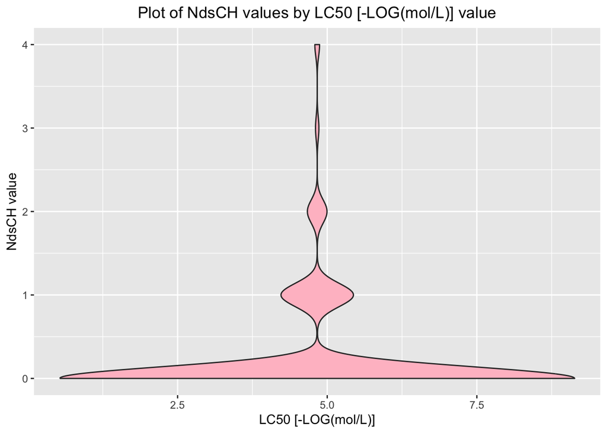

```r
g <- ggplot(fish, aes(x = `LC50 [-LOG(mol/L)]`,y = NdsCH))
g + geom_violin(fill = "pink") + labs(title = "Plot of NdsCH values by LC50 [-LOG(mol/L)] value", x ="LC50 [-LOG(mol/L)]", y = "NdsCH value") + theme(plot.title = element_text(hjust = 0.5))
```

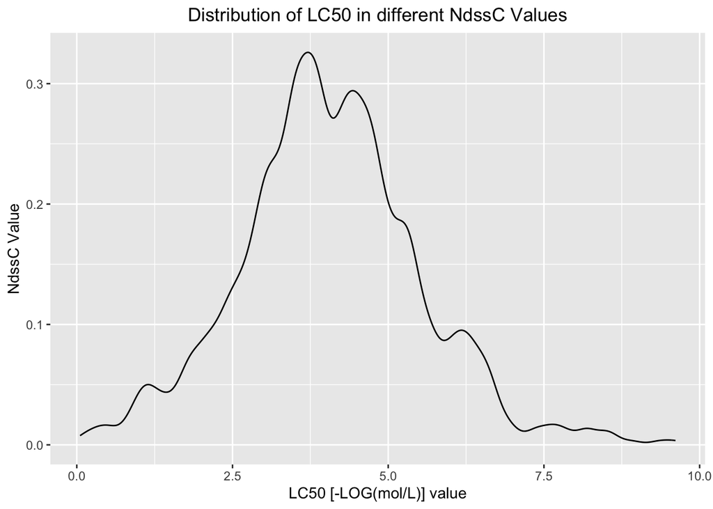

```r
g <- ggplot(data = fish, aes(x = `LC50 [-LOG(mol/L)]`))
g + geom_density(adjust = 0.5, alpha = 0.5, aes(fill = NdssC)) + labs(title = "Distribution of LC50 in different NdssC Values", x ="LC50 [-LOG(mol/L)] value", y = "NdssC Value") + theme(plot.title = element_text(hjust = 0.5))
```

3. The fourth plot is a scatter plot. Which shows the relationship between SM1_Dz(Z) values and LC50 [-LOG(mol/L)] value.

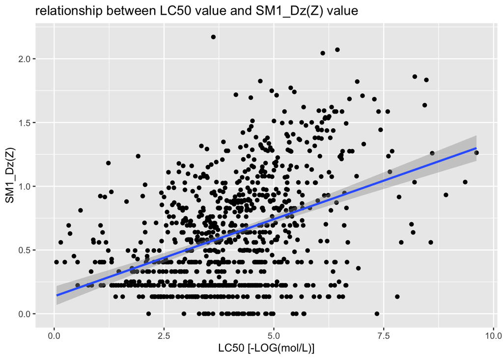

```r
g <- ggplot(data = fish, aes(x = `LC50 [-LOG(mol/L)]`, y = `SM1_Dz(Z)`))
g + geom_point(size = 1.5) + geom_smooth(formula = y ~ x,method = lm) + labs(x = "LC50 [-LOG(mol/L)]", title = "relationship between LC50 value and SM1_Dz(Z) value")
```

## Investigate relationships between the variables in terms of their medians.

Use the apply() function to apply this function to each column of the data frame

```r
medianfish <- function(x) {
  ifelse (x <= median(x), "low", "High")
}
fishMedian <- apply(X = fish %>% select(everything()),
             MARGIN = 2,
             FUN = medianfish
             )
```

Create a two-way contingency table with corresponding side-by- side/stacked bar plot visual using the binary LC50 variable and CIC0 variable.

```r
fishnew <- as.data.frame(fishMedian)
table(fishnew$`LC50 [-LOG(mol/L)]`,fishnew$CIC0)
```

```
##
##        High low
##   High  273 181
##   low   181 273
```

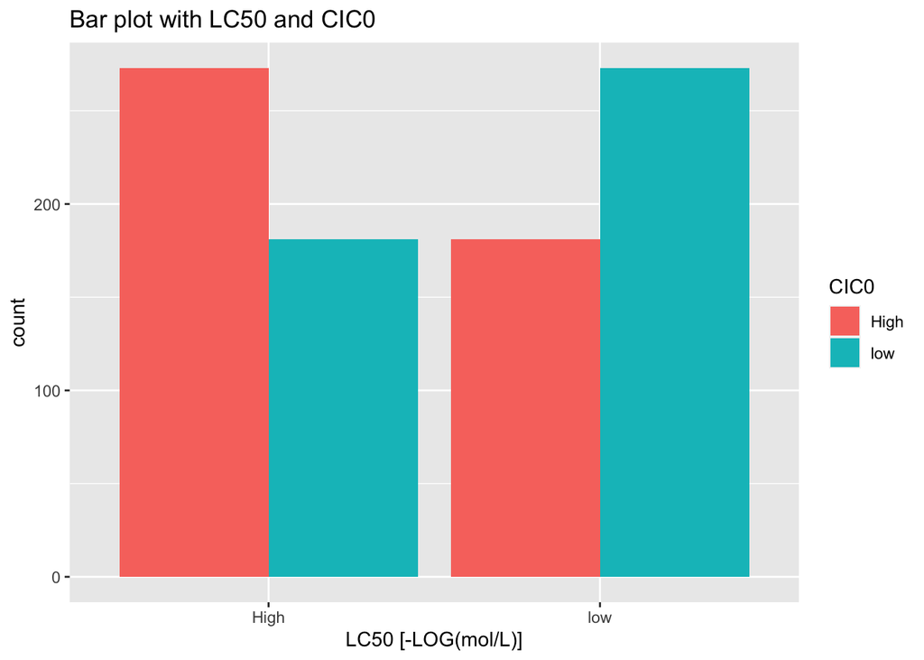

```r
ggplot(data = fishnew, aes(x = `LC50 [-LOG(mol/L)]`, fill = CIC0)) + geom_bar(position = "dodge") + labs(title = "Bar plot with LC50 and CIC0")
```

Create a two-way contingency table with corresponding side-by- side/stacked bar plot visual using the binary LC50 variable and NdsCH variable.

```r
fishnew <- as.data.frame(fishMedian)
table(fishnew$`LC50 [-LOG(mol/L)]`,fishnew$NdsCH)
```

```
##
##        High low
##   High   90 364
##   low    58 396
```

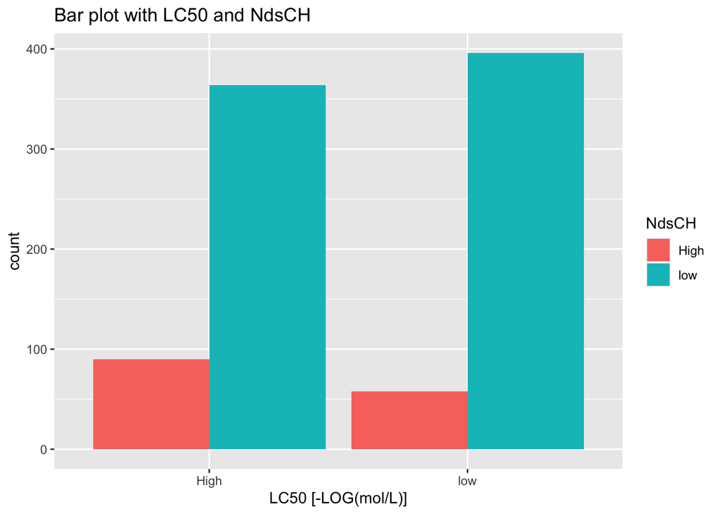

```r
ggplot(data = fishnew, aes(x = `LC50 [-LOG(mol/L)]`, fill = NdsCH)) + geom_bar(position = "dodge")+ labs(title = "Bar plot with LC50 and NdsCH")
```

##Fit four different linear regression models. - At least one model should include a polynomial term - At least one model should include an interaction term

1. The first linear regression model.

```r
mod1 <- lm(`LC50 [-LOG(mol/L)]` ~ CIC0, data = fish)
summary(mod1)
```

```
##
## Call:
## lm(formula = `LC50 [-LOG(mol/L)]` ~ CIC0, data = fish)
##
## Residuals:
##     Min      1Q  Median      3Q     Max
## -3.9046 -0.8658 -0.0646  0.8081  4.6925
##
## Coefficients:
##             Estimate Std. Error t value Pr(>|t|)
## (Intercept)  2.43595    0.18323  13.294   <2e-16 ***
## CIC0         0.56191    0.06118   9.185   <2e-16 ***
## ---
## Signif. codes:  0 '***' 0.001 '**' 0.01 '*' 0.05 '.' 0.1 ' ' 1
##
## Residual standard error: 1.393 on 906 degrees of freedom
## Multiple R-squared:  0.08518,    Adjusted R-squared:  0.08417
## F-statistic: 84.36 on 1 and 906 DF,  p-value: < 2.2e-16
```

2. The second linear regression model.

```r
mod2 <- lm(`LC50 [-LOG(mol/L)]`~ CIC0 + NdsCH + MLOGP +GATS1i, data = fish)
summary(mod2)
```

```
##
## Call:
## lm(formula = `LC50 [-LOG(mol/L)]` ~ CIC0 + NdsCH + MLOGP + GATS1i,
##     data = fish)
##
## Residuals:
##     Min      1Q  Median      3Q     Max
## -3.5239 -0.6614 -0.1344  0.5430  6.0267
##
## Coefficients:
##             Estimate Std. Error t value Pr(>|t|)
## (Intercept)  3.29372    0.18078  18.220  < 2e-16 ***
## CIC0         0.07154    0.06001   1.192    0.233
## NdsCH        0.33344    0.05934   5.619 2.55e-08 ***
## MLOGP        0.56915    0.03485  16.333  < 2e-16 ***
## GATS1i      -0.55158    0.11350  -4.860 1.38e-06 ***
## ---
## Signif. codes:  0 '***' 0.001 '**' 0.01 '*' 0.05 '.' 0.1 ' ' 1
##
## Residual standard error: 1.073 on 903 degrees of freedom
## Multiple R-squared:  0.4593, Adjusted R-squared:  0.4569
## F-statistic: 191.8 on 4 and 903 DF,  p-value: < 2.2e-16
```

3. The third linear regression model.

```r
mod3 <- lm(`LC50 [-LOG(mol/L)]`~ CIC0 + NdsCH + MLOGP +GATS1i:NdsCH, data = fish)
summary(mod3)
```

```
##
## Call:
## lm(formula = `LC50 [-LOG(mol/L)]` ~ CIC0 + NdsCH + MLOGP + GATS1i:NdsCH,
##     data = fish)
##
## Residuals:
##     Min      1Q  Median      3Q     Max
## -3.7351 -0.6489 -0.1231  0.5045  6.3368
##
## Coefficients:
##              Estimate Std. Error t value Pr(>|t|)
## (Intercept)   2.74579    0.14373  19.104   <2e-16 ***
## CIC0         -0.05883    0.05451  -1.079    0.281
## NdsCH         0.41942    0.27243   1.540    0.124
## MLOGP         0.66843    0.02873  23.268   <2e-16 ***
## NdsCH:GATS1i -0.05740    0.20694  -0.277    0.782
## ---
## Signif. codes:  0 '***' 0.001 '**' 0.01 '*' 0.05 '.' 0.1 ' ' 1
##
## Residual standard error: 1.087 on 903 degrees of freedom
## Multiple R-squared:  0.4452, Adjusted R-squared:  0.4428
## F-statistic: 181.2 on 4 and 903 DF,  p-value: < 2.2e-16
```

4. The fourth linear regression model.

```r
mod4 <- lm(`LC50 [-LOG(mol/L)]`~ CIC0 + NdsCH + MLOGP +GATS1i:NdsCH, data = fish)
summary(mod4)
```

```
##
## Call:
## lm(formula = `LC50 [-LOG(mol/L)]` ~ CIC0 + NdsCH + MLOGP + GATS1i:NdsCH,
##     data = fish)
##
## Residuals:
##     Min      1Q  Median      3Q     Max
## -3.7351 -0.6489 -0.1231  0.5045  6.3368
##
## Coefficients:
##              Estimate Std. Error t value Pr(>|t|)
## (Intercept)   2.74579    0.14373  19.104   <2e-16 ***
## CIC0         -0.05883    0.05451  -1.079    0.281
## NdsCH         0.41942    0.27243   1.540    0.124
## MLOGP         0.66843    0.02873  23.268   <2e-16 ***
## NdsCH:GATS1i -0.05740    0.20694  -0.277    0.782
## ---
## Signif. codes:  0 '***' 0.001 '**' 0.01 '*' 0.05 '.' 0.1 ' ' 1
##
## Residual standard error: 1.087 on 903 degrees of freedom
## Multiple R-squared:  0.4452, Adjusted R-squared:  0.4428
## F-statistic: 181.2 on 4 and 903 DF,  p-value: < 2.2e-16
```

5. Use mod4 to build a mutiple linear regression which include LC50, CIC0,NDsCH, MLOGP, GATS1i and polynomial term which is CIC0^2.

```r
mod4 <- lm(`LC50 [-LOG(mol/L)]`~ CIC0 + NdsCH + MLOGP +GATS1i+I(CIC0^2), data = fish)
summary(mod4)
```

```
##
## Call:
## lm(formula = `LC50 [-LOG(mol/L)]` ~ CIC0 + NdsCH + MLOGP + GATS1i +
##     I(CIC0^2), data = fish)
##
## Residuals:
##     Min      1Q  Median      3Q     Max
## -3.8930 -0.6458 -0.1348  0.5008  5.8151
##
## Coefficients:
##             Estimate Std. Error t value Pr(>|t|)
## (Intercept)  4.76600    0.42302  11.267  < 2e-16 ***
## CIC0        -0.92153    0.26518  -3.475 0.000535 ***
## NdsCH        0.30114    0.05949   5.062 5.03e-07 ***
## MLOGP        0.53867    0.03548  15.182  < 2e-16 ***
## GATS1i      -0.63362    0.11464  -5.527 4.27e-08 ***
## I(CIC0^2)    0.17654    0.04594   3.843 0.000130 ***
## ---
## Signif. codes:  0 '***' 0.001 '**' 0.01 '*' 0.05 '.' 0.1 ' ' 1
##
## Residual standard error: 1.065 on 902 degrees of freedom
## Multiple R-squared:  0.468,  Adjusted R-squared:  0.4651
## F-statistic: 158.7 on 5 and 902 DF,  p-value: < 2.2e-16
```

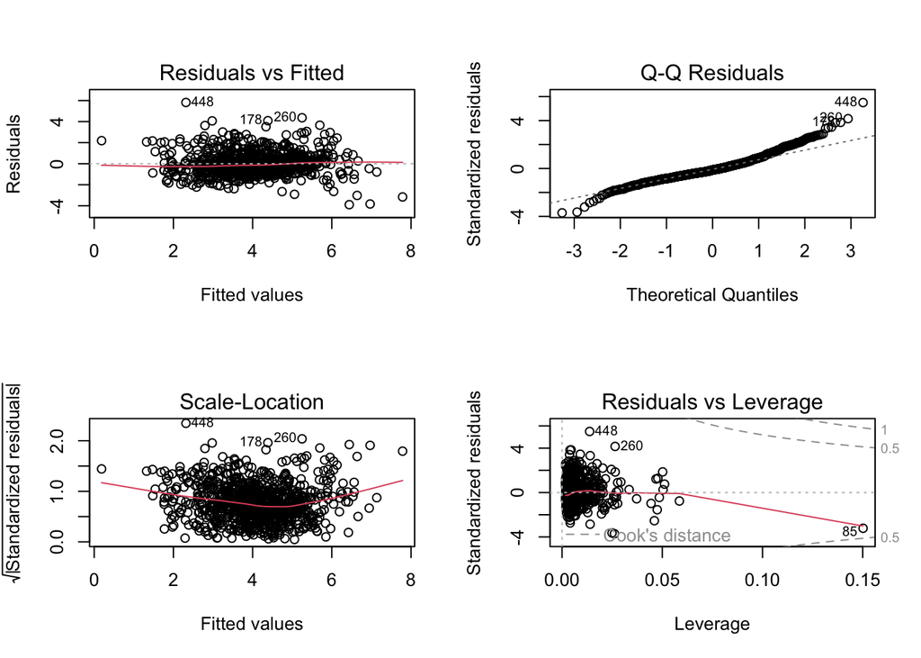

```r
par(mfrow = c(2,2))
plot(mod4)
```

##Predicting LC50 value use mod1 to predict LC50 value.

```r
predict(mod1, newmod = data.frame(CIC0 = median(fish$CIC0)))
```

[output not shown]

[output cut: 173 more lines]

[output not shown]

use mod2 to predict LC50 value.

```r
predict(mod2, newmod = data.frame(CIC0 = median(fish$CIC0), NdsCH = median(fish$NdsCH), MLOGP = median(fish$MLOGP), GATS1i=median(fish$GATS1i)))
```

[output not shown]

[output cut: 173 more lines]

[output not shown]